# 12 IRT

Rushabh Barbhaya

2021-02-14

## Dichotomous IRT Class Assignment

The included dataset includes data from an Educational Psychology Test scored as 0 (answered incorrectly) and 1 (answered correctly). Import the data (assignment_dirt.csv) and libraries below.

```r
library(ltm)
library(mirt)
data = read.csv("assignment_dirt.csv", header = F)
```

## Two Parameter Logistic

Include a 2PL calculated on just columns V2 through V5. Save the model as `edu.model`. Use the `coef()` function to examine the difficulty and discrimination parameters.

```r
data = data[, 2:5]
summary(data)
```

```
##        V2            V3               V4               V5
##  Min.   :0.0   Min.   :0.0000   Min.   :0.0000   Min.   :0.0000
##  1st Qu.:0.0   1st Qu.:1.0000   1st Qu.:0.2500   1st Qu.:1.0000
##  Median :1.0   Median :1.0000   Median :1.0000   Median :1.0000
##  Mean   :0.7   Mean   :0.9333   Mean   :0.7333   Mean   :0.8667
##  3rd Qu.:1.0   3rd Qu.:1.0000   3rd Qu.:1.0000   3rd Qu.:1.0000
##  Max.   :1.0   Max.   :1.0000   Max.   :1.0000   Max.   :1.0000
```

```r
edu.model = ltm(data ~ z1, IRT.param = T)
coef(edu.model)
```

```
##        Dffclt    Dscrmn
## V2 -0.6709885 2.0380646
## V3 -3.1003782 0.9793271
## V4 -0.7307125 2.5908115
## V5 -1.3209210 2.6748421
```

## 2PL Plots

Include the ICC and TIF plots to view all the items and overall test information at once.

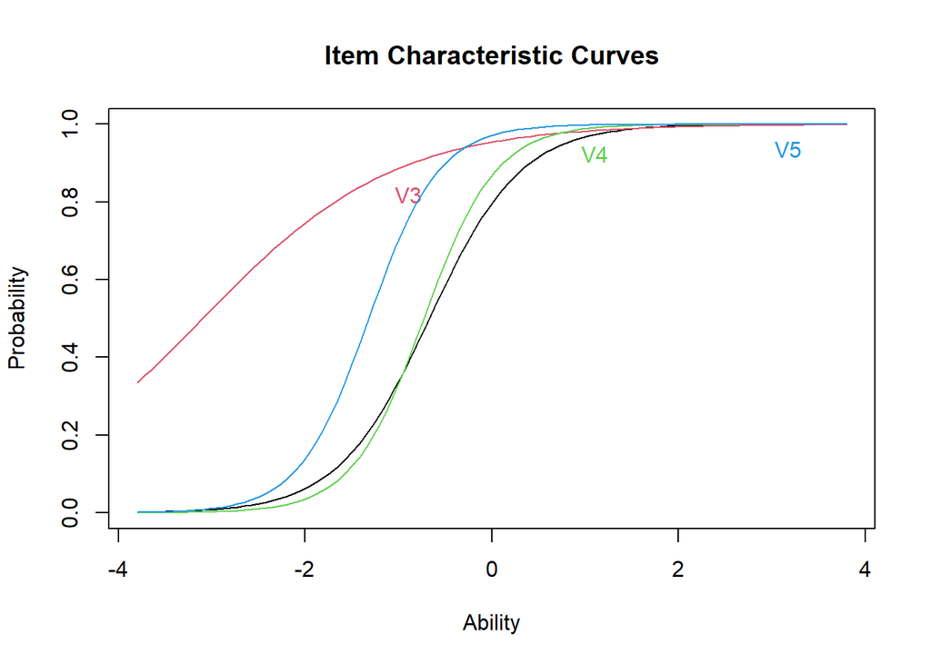

```r
plot(edu.model, type = "ICC")
```

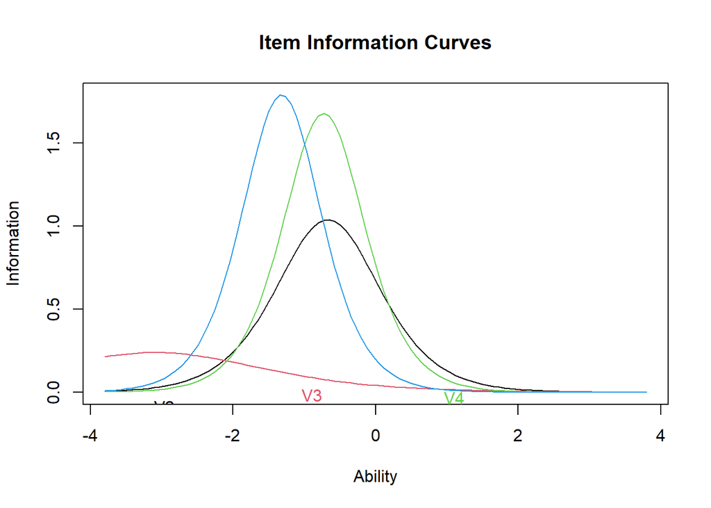

```r
plot(edu.model, type = "IIC")
```

```r
factor.scores(edu.model)
```

```
##
## Call:
## ltm(formula = data ~ z1, IRT.param = T)
##
## Scoring Method: Empirical Bayes
##
## Factor-Scores for observed response patterns:
##   V2 V3 V4 V5 Obs    Exp     z1 se.z1
## 1  0  0  0  0   1  0.501 -1.763 0.558
## 2  0  1  0  0   2  1.905 -1.496 0.494
## 3  0  1  0  1   2  2.349 -0.929 0.447
## 4  0  1  1  1   4  3.270 -0.360 0.512
## 5  1  0  1  1   1  0.571 -0.039 0.599
## 6  1  1  0  1   3  2.328 -0.497 0.485
## 7  1  1  1  0   1  0.468 -0.517 0.482
## 8  1  1  1  1  16 16.692  0.397 0.744
```

```r
person.fit(edu.model)
```

```
##
## Person-Fit Statistics and P-values
##
## Call:
## ltm(formula = data ~ z1, IRT.param = T)
##
## Alternative: Inconsistent response pattern under the estimated model
##
##   V2 V3 V4 V5      L0      Lz Pr(<Lz)
## 1  0  0  0  0 -1.9844 -0.3072  0.3793
## 2  0  1  0  0 -0.9751  0.8728  0.8086
## 3  0  1  0  1 -1.3466  1.0112   0.844
## 4  0  1  1  1 -1.5231  0.1935  0.5767
## 5  1  0  1  1 -3.4764 -1.8457  0.0325
## 6  1  1  0  1 -1.7522  0.1603  0.5637
## 7  1  1  1  0 -3.3397 -1.4303  0.0763
## 8  1  1  1  1 -0.2018  0.4412  0.6705
```

```r
item.fit(edu.model)
```

```
##
## Item-Fit Statistics and P-values
##
## Call:
## ltm(formula = data ~ z1, IRT.param = T)
##
## Alternative: Items do not fit the model
## Ability Categories: 10
##
##        X^2 Pr(>X^2)
## V2 14.1213   0.0283
## V3 25.5185   0.0003
## V4 10.1663   0.1178
## V5 11.6772   0.0696
```

## Three Parameter Logistic

Include the 3PL model as `edu2.model`. Use the `coef()` function to examine the difficulty, discrimination, and guessing parameters.

```r
edu2.model= tpm(data, type = "latent.trait", IRT.param = T)
options(scipen = 999)
coef(edu2.model)
```

```
##            Gussng     Dffclt    Dscrmn
## V2 0.000032277996 -0.6707705 2.0387253
## V3 0.000012051267 -3.1011496 0.9789238
## V4 0.000007330238 -0.7306659 2.5912676
## V5 0.000015353271 -1.3209198 2.6745913
```

## 3PL Plots

Include the ICC and TIF plots to view all the items and overall test information at once.

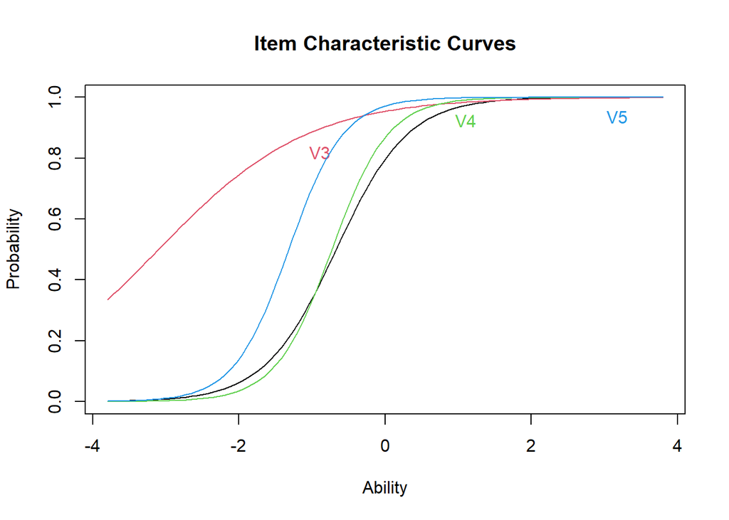

```r
plot(edu2.model, type = "ICC")
```

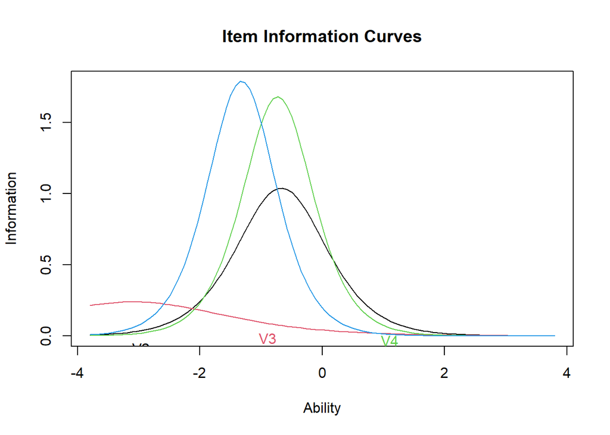

```r
plot(edu2.model, type = "IIC")
```

## Compare Models

Use the `anova()` function to compare the two models.

```r
anova(edu.model, edu2.model)
```

```
##
##  Likelihood Ratio Table
##               AIC    BIC log.Lik LRT df p.value
## edu.model  113.48 124.68  -48.74
## edu2.model 121.48 138.29  -48.74   0  4       1
```

QUESTION: Which model was better? Does it appear that the guessing parameter adds something useful to the model? ANSWER: Both models don’t seem to be much different from each other. If we have to answer, it’s model 1

QUESTION: Which items would be considered good items based on discrimination? ANSWER: Model2

## Polytomous IRT

Load the assignment_mirt data below. You should reverse code items 5, 8, and 13 using `8 - columns` to ensure all items are in the same direction. The scale included examines evaluations of job candidates rated on 15 different qualities.

```r
master = read.csv("assignment_mirt.csv")

master$q5 = 8 - master$q5
master$q8 = 8 - master$q8
master$q13 = 8 - master$q13
```

## Graded Partial Credit Model

Create a graded partial credit model to analyze the scale, and save this model as `gpcm.model`. Include the `coef()` for the model to help you answer the questions below.

```r
gpcm.model = mirt(data = master, model = 1, itemtype = "gpcm")
```

[output not shown]

[output cut: 446 more lines]

[output not shown]

```
## EM cycles terminated after 500 iterations.
```

```r
summary(gpcm.model)
```

```
##        F1     h2
## q1  0.594 0.3525
## q2  0.597 0.3562
## q3  0.764 0.5844
## q4  0.560 0.3134
## q5  0.315 0.0992
## q6  0.511 0.2610
## q7  0.662 0.4377
## q8  0.252 0.0633
## q9  0.429 0.1843
## q10 0.629 0.3953
## q11 0.619 0.3837
## q12 0.576 0.3319
## q13 0.391 0.1526
## q14 0.609 0.3705
## q15 0.564 0.3180
##
## SS loadings:  4.604
## Proportion Var:  0.307
##
## Factor correlations:
##
##    F1
## F1  1
```

```r
coef(gpcm.model, IRTpars = T)
```

```
## $q1
##         a     b1     b2     b3     b4     b5
## par 1.256 -2.782 -1.562 -1.957 -1.154 -0.145
##
## $q2
##         a     b1     b2    b3     b4    b5    b6
## par 1.266 -1.148 -2.956 -0.77 -1.341 -0.62 0.924
##
## $q3
##         a     b1     b2   b3     b4     b5    b6
## par 2.018 -1.685 -2.107 -0.7 -1.239 -0.215 1.083
##
## $q4
##        a     b1     b2     b3     b4     b5    b6
## par 1.15 -2.245 -1.647 -1.923 -1.002 -0.296 1.704
##
## $q5
##         a     b1     b2     b3     b4     b5    b6
## par 0.565 -2.824 -2.112 -1.194 -0.619 -1.187 0.848
##
## $q6
##         a     b1     b2     b3     b4   b5    b6
## par 1.011 -2.433 -1.945 -1.646 -0.654 0.18 1.716
##
## $q7
##         a     b1     b2     b3     b4     b5    b6
## par 1.502 -1.793 -2.382 -1.126 -1.123 -0.282 0.931
##
## $q8
##         a     b1     b2    b3     b4     b5    b6
## par 0.442 -1.222 -1.983 0.664 -0.719 -0.266 2.281
##
## $q9
##         a     b1    b2     b3     b4     b5    b6
## par 0.809 -2.206 -3.01 -2.169 -1.203 -0.224 1.442
##
## $q10
##         a     b1     b2     b3     b4    b5
## par 1.376 -1.015 -3.263 -1.298 -1.072 0.024
##
```

[output cut: 8 more lines]

```
## $q13
##         a     b1     b2     b3     b4    b5     b6
## par 0.722 -4.214 -0.531 -2.284 -0.964 -1.47 -1.079
##
## $q14
##         a     b1     b2     b3     b4    b5    b6
## par 1.306 -1.782 -2.359 -1.645 -0.628 0.108 1.448
##
## $q15
##         a     b1     b2     b3     b4    b5
## par 1.162 -1.783 -2.483 -0.905 -0.532 0.516
##
## $GroupPars
##     MEAN_1 COV_11
## par      0      1
```

## GPCM Plots

Include the ICC and TIF plots to view all the items and overall test information at once.

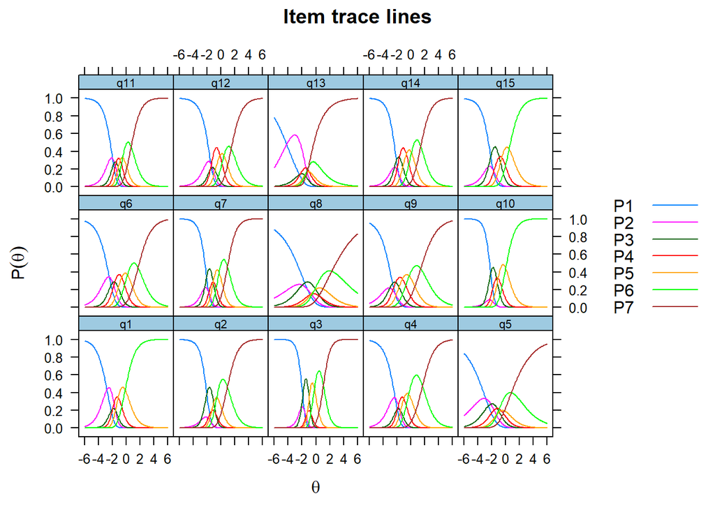

```r
plot(gpcm.model, type = "trace")
```

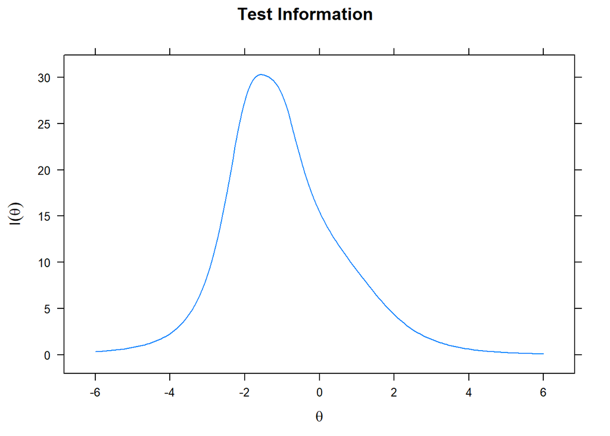

```r
plot(gpcm.model, type = "info")
```

```r
fscores(gpcm.model)
```

```
##                  F1
##   [1,] -1.753951471
##   [2,] -1.707938891
##   [3,] -1.127109686
##   [4,] -1.503975283
##   [5,] -0.733065204
##   [6,] -1.171987082
##   [7,] -1.205518678
##   [8,] -1.290134815
##   [9,] -0.356157951
##  [10,] -0.881753286
##  [11,] -0.706653959
##  [12,] -1.182414100
##  [13,] -1.182414100
##  [14,] -1.275962787
```

[output cut: 157 more lines]

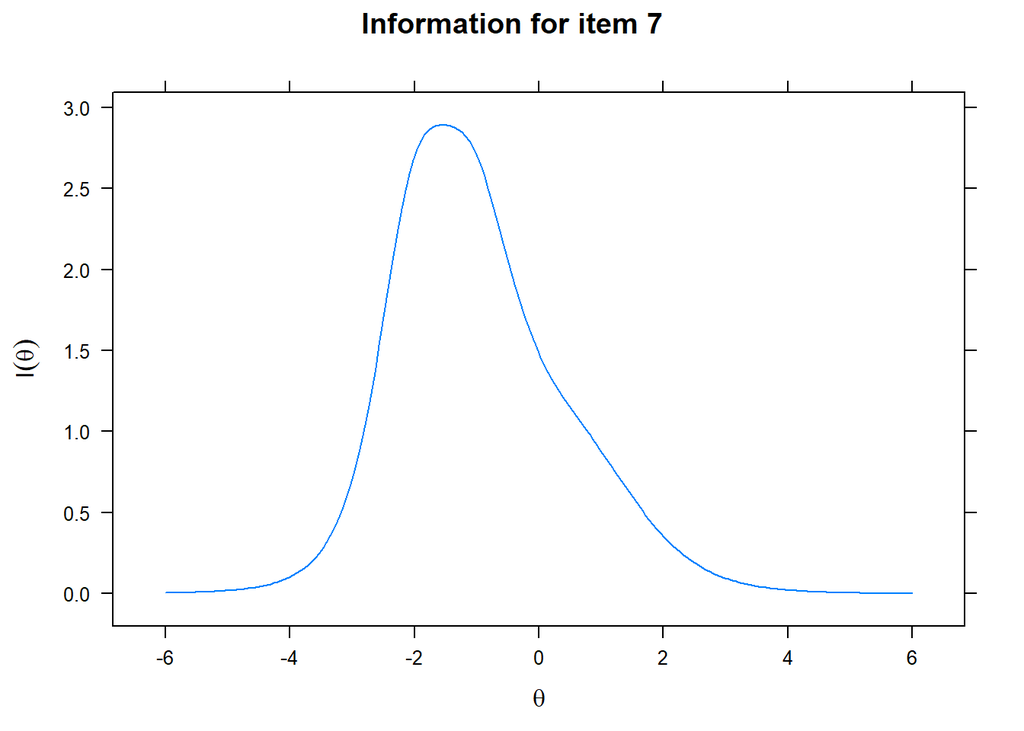

```r
itemplot(gpcm.model, 7, type = "info")
```

QUESTION: Examine the items. Do they appear ordered where each answer function is ordered correctly from 1 to 7? ANSWER: Averages are below 0

QUESTION: Examine the items. Do we need all 7 items on this scale? (i.e., do they all have the probability of being the most likely answer choice?) ANSWER: Averages are below 0

QUESTION: Which items indicate good discrimination? ANSWER: 5, 8 and 13 are bad. Rest look good.